Pi GUI · 使用手册

# Pi GUI 功能说明

# Pi GUI 功能说明

> 面向JetBrains IDE 用户的 Pi GUI 使用手册。本文按仓库当前实现整理；界面截图来自本次提供的采集素材，菜单文案和模型列表会因本机 pi、供应商配置及插件版本而不同。

## 1. 产品简介

Pi GUI 是 JetBrains IDE 内使用 [pi 编程智能体](https://github.com/earendil-works/pi) 的插件。它把聊天、会话历史、模型和思考参数、技能与扩展配置，以及 IDE 文件操作整合在一个工具窗口里。插件以本机 `pi --mode rpc` 子进程工作，通过标准输入/输出传递 JSON-RPC 风格的逐行消息；聊天和设置界面使用 IDE 自带的 JCEF，项目集成和对话框使用 IntelliJ Platform 原生组件，不启动本地 Web 服务，也不加载远程 UI 页面。

## 2. 安装与首次启动

### 环境要求

- JetBrains IDE build 243（2024.3）或更新版本。
- 本机安装 pi CLI：

  ```bash
  npm i -g @earendil-works/pi-coding-agent
  ```

- 另外也可以使用Pi Gui 插件**一键安装**。

### 安装插件

1. 在 IDE 打开 **Settings → Plugins → ⚙ → Marketplace**，搜索选择 Pi GUI 插件 ZIP。

[figure not shown]

   插件市场

2. 按 IDE 提示重启。
3. 点击右侧工具栏的 **Pi GUI**，或使用快捷键 **Alt+Shift+P** 打开。

> 插件市场/磁盘安装页面会显示实际安装的插件名称和版本。若面板无法启动，先在 **Settings → Plugins → Installed** 确认插件已启用，再在 Pi GUI 设置的 **pi CLI** 页面检查可执行文件路径。

## 3. 聊天窗口

[figure not shown]

Pi GUI 聊天窗口与输入区

工具窗口由会话历史区、聊天记录和底部输入区组成。输入区可输入自然语言或 `/` 命令，并提供附件、模型供应商、模型、思考强度、上下文压缩与发送控件。空白会话会显示 Pi 欢迎页；读取历史记录不会启动 pi 进程，发送消息时才启动或恢复会话。

### 新建会话、发送与继续引导

1. 点击会话栏顶部的 **＋** 建立新会话。
2. 在输入区描述任务；回车发送或点击 **Send**。可在设置中调整 Enter 与 Shift+Enter 的发送/换行行为。
3. Pi 的文本、思考块和工具调用会逐步流入聊天记录。
4. 智能体运行期间仍可提交后续指示；新消息会作为 steering 请求排队，由当前运行处理。

**停止生成：**运行时可使用输入区出现的停止控件中断当前运行。具体控件显示随版本及运行状态变化。

### 消息显示与代码

- Markdown 内容支持标题、列表、表格、引用、链接和行内代码。
- 围栏代码块使用 IDE 语法高亮，并提供复制按钮。
- 思考内容、工具调用及工具结果可折叠，以减少长对话中的视觉噪声；点击区块可展开。
- 每次响应附带模型、Token 用量、缓存命中率、耗时和费用信息；悬停可查看提示词/输出及缓存/非缓存 Token 的细项。
- 运行期间状态区域显示实时计时；结束后显示总耗时，并展示当前 Git 分支。

## 4. 会话历史与分支

Pi GUI 按当前项目列出 pi 会话，通常按最近更新时间倒序排列。历史来自 `~/.pi/agent/sessions/`，打开已有会话时不必先启动智能体。

- 点击会话可恢复对话并继续发送消息。
- 会话列表支持键盘 Delete 删除所选会话；请在确认目标后操作。
- 会话记录是树形结构。聊天只呈现当前分支从根到活动叶子的路径；已放弃分支不会混进当前对话。
- `/tree` 用于切换会话分支，`/fork` 从先前用户消息建立分叉，`/clone` 在当前位置复制会话。
- `/resume` 用于选择另一个历史会话；`/session` 查看当前会话信息和统计；`/name` 设置会话显示名。

## 5. 输入区控制

### 供应商与模型

先选择供应商，再选择该供应商提供的模型。更换供应商后，模型菜单会按其可用模型更新。当前菜单示例：

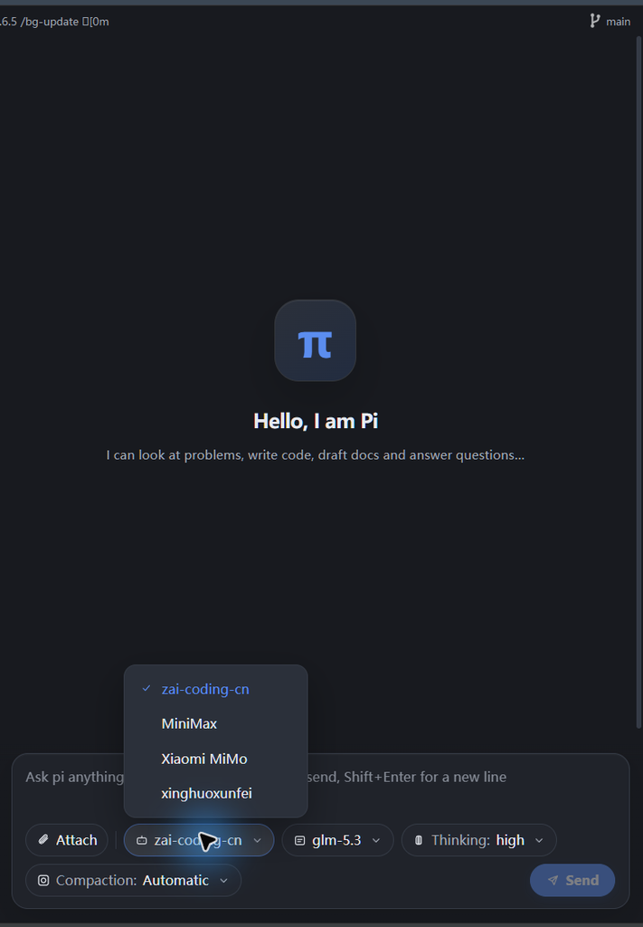

聊天中的供应商选择菜单

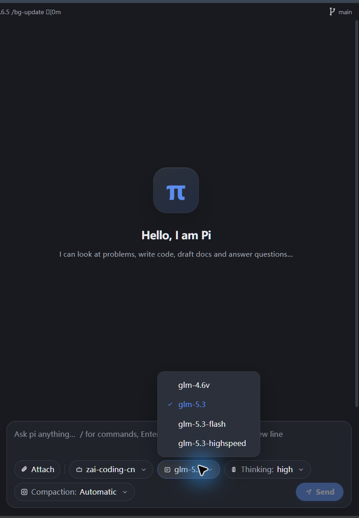

聊天中的模型选择菜单

新会话使用当前启用的供应商及其默认模型。若模型不可选或请求鉴权失败，请检查供应商配置、模型名、Base URL 与凭据。

### 思考强度

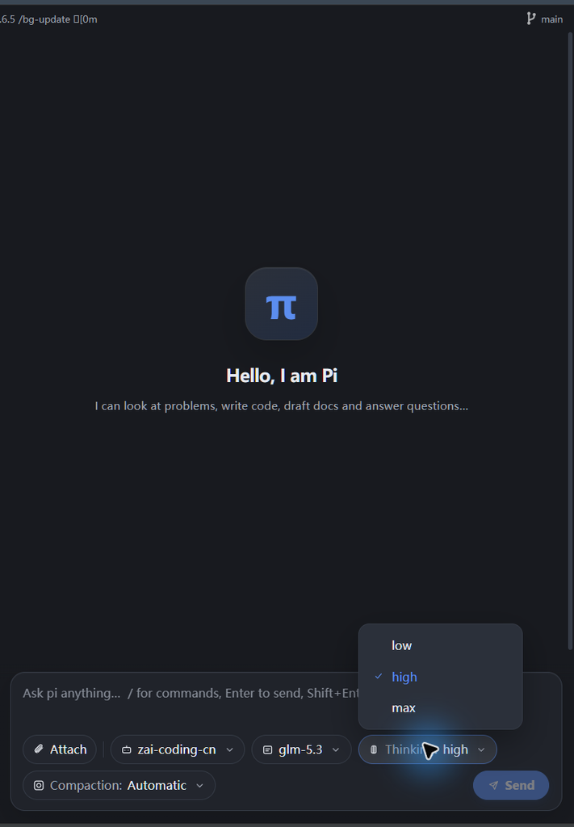

思考强度菜单

点击 **Thinking** 控件选择模型支持的推理级别，例如 low、high 或 max。高强度适合复杂分析，通常需要更多等待时间和上下文用量；实际选项由所选模型决定。

### 上下文压缩

[figure not shown]

上下文压缩菜单

**Compaction** 控件显示自动/手动模式及当前上下文占用。可选择自动压缩，或在菜单中执行 **Compact now**。若上下文太少，界面可能提示当前不值得压缩；需要强制操作时可以输入 `/compact`。

[figure not shown]

低上下文时的压缩提示

### 附件

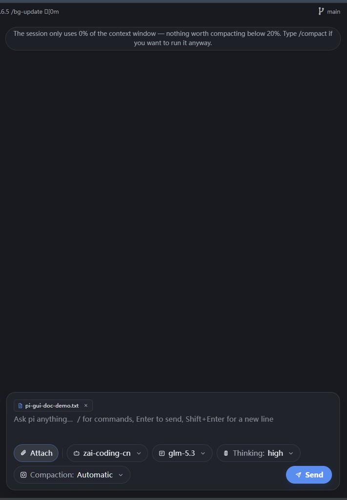

输入区附件示例

通过 **Attach**、拖放文件到输入区或粘贴添加附件。图片（PNG、JPG、GIF、WebP、BMP）以图片内容随消息发送，最多 10 张、单张不超过 10 MB；其他文件以 `@path` 引用提供给智能体读取，避免把大型日志或表格直接塞进上下文。发送前可以从输入区移除附件。

## 6. 斜杠命令

在输入区开头输入 `/` 打开命令补全。方向键移动，Enter 或 Tab 选中，Escape 关闭。列表包含 pi 的 23 个内置命令，以及 pi 返回的扩展命令、提示词模板和技能。内置命令即时显示，动态命令在 pi 返回后补入。

插件直接处理 pi 只在交互式终端里可运行的命令，避免把 `/new` 等误当作普通提示词发送给模型。

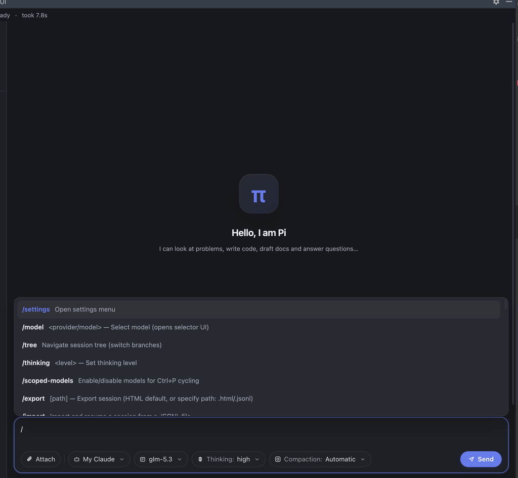

斜杠命令

| 命令 | 用途与处理方式 |
| --- | --- |
| `/settings` | 打开 Pi GUI 设置 |
| `/model [provider/model]` | 打开模型选择器或切换模型 |
| `/thinking [level]` | 选择思考级别 |
| `/new` | 新建会话 |
| `/resume` | 恢复另一条会话 |
| `/tree` | 浏览并切换会话树分支 |
| `/compact` | 手动压缩上下文 |
| `/session` | 显示会话信息与统计 |
| `/name [name]` | 设置会话名称 |
| `/copy` | 复制最近一条智能体消息 |
| `/export [path]` | 导出会话（默认 HTML，也可指定 `.html`/`.jsonl` 路径） |
| `/clone` | 在当前位置复制会话 |
| `/fork` | 从先前用户消息创建分支 |
| `/hotkeys` | 显示快捷键说明 |
| `/reload` | 重新加载快捷键、扩展、技能、提示词、主题和上下文文件 |
| `/quit` | 退出 pi |
| `/login <provider>`、`/logout` | 需要在 pi 终端完成供应商身份验证 |
| `/trust` | 在 pi 终端保存项目受信任决策 |
| `/share` | 需要 pi 终端交互，分享为私密 GitHub gist |
| `/import` | 需要 pi 终端交互，从 JSONL 导入并恢复会话 |
| `/changelog` | 需要 pi 终端显示更新记录 |
| `/scoped-models` | 需要 pi 终端设置 Ctrl+P 模型循环范围 |

表格后六项终端专属命令会显示说明，不会作为提示词提交。命令的可用性仍受 pi 版本和扩展实现影响。

## 7. IDE 项目集成

### 发送文件路径到对话

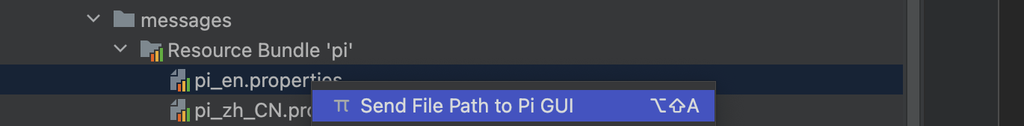

发送文件到对话1

[figure not shown]

发送文件到对话2

### 查看智能体改动

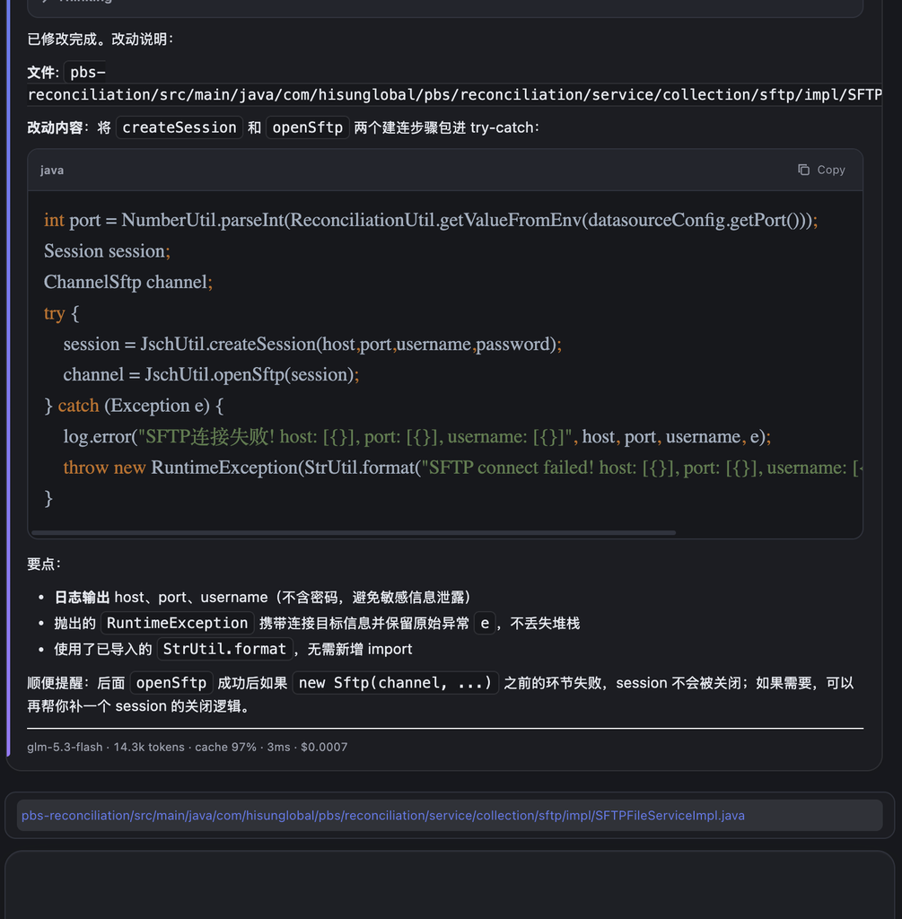

查看代码改动

### Git 分支

[figure not shown]

git分支

Pi GUI 状态栏展示当前检出的分支。插件直接读取仓库 `.git/HEAD`，不依赖 JetBrains Git 插件；分支切换后会刷新状态。

### 根据变更生成提交说明

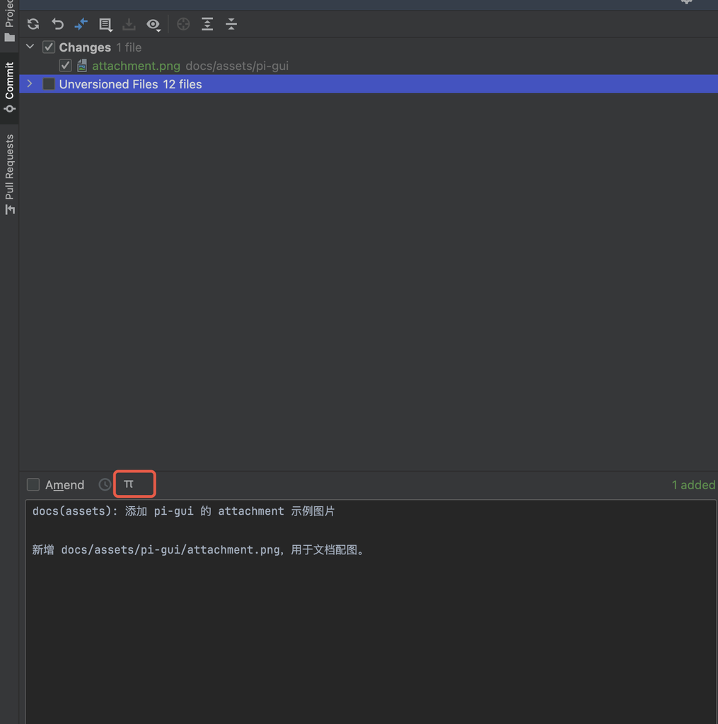

git commit ai

在 IDE 原生 Commit 工具栏使用 Pi 图标，可根据当前纳入提交的变更生成提交说明并填入提交消息框。此操作只生成文本，不会执行 commit；生成结果可由用户编辑后再决定是否提交。

## 8. 设置说明

点击 Pi GUI 工具窗口工具栏的齿轮打开设置。IDE 设置页也可通过 **Settings → Tools → Pi GUI** 进入。设置界面目前包含 **常规、pi CLI、模型供应商、技能、MCP 服务、插件、Commit AI** 七个页面；下表逐页列出可用功能。

| 页面 | 可配置内容 |
| --- | --- |
| **General** | 系统/浅色/深色主题；显示思考过程；默认展开思考区和工具调用；Enter 发送；聊天字体大小；界面语言（英文、简体中文、繁体中文） |
| **pi CLI** | 查看自动探测结果；选择/填写 pi 可执行文件路径；未安装或未探测到时可从设置页启动一键安装（运行 pi.dev 提供的安装命令，会先显示确认）；配置每次启动附加的 CLI 参数，例如 `--models "anthropic/*"` |
| **模型供应商** | 查看按 Claude Code（Anthropic）和 Codex（OpenAI）分类的供应商；从 cc-switch 自动导入/更新或选择 `cc-switch.db` 导入；启用供应商、编辑名称/Base URL/API Key/模型列表、删除供应商；显示当前供应商标记。留空 API Key 可保留已存密钥，已保存密钥不会回显到编辑页 |
| **技能** | 浏览全局及项目技能、查看名称/说明/路径/作用范围；开关控制技能是否提供给 agent；搜索 skills.sh，并将技能安装到全局或当前项目 |
| **MCP 服务** | 搜索、刷新和查看 MCP 服务；新增、编辑、删除服务；启用/停用；查看配置状态、作用范围、传输方式及启动方式；配置全局或当前项目服务 |
| **插件** | 在 pi.dev/packages 搜索插件包，或填写来源安装（npm、git URL、本地路径）；选全局或项目范围；查看已安装包及包内扩展/技能/提示词/主题数量；刷新和移除包 |
| **Commit AI** | 选择提交说明生成模型（跟随聊天模型或选定模型）、输出中文/英文、设置额外提示词、恢复默认提示词；只分析 Commit 面板中选中的变更，不会自动提交 |

设置页面支持保存/自动保存。界面语言修改后生效；需要刷新技能、插件、MCP 或供应商配置的运行会话时，按对应提示新建会话或重载。

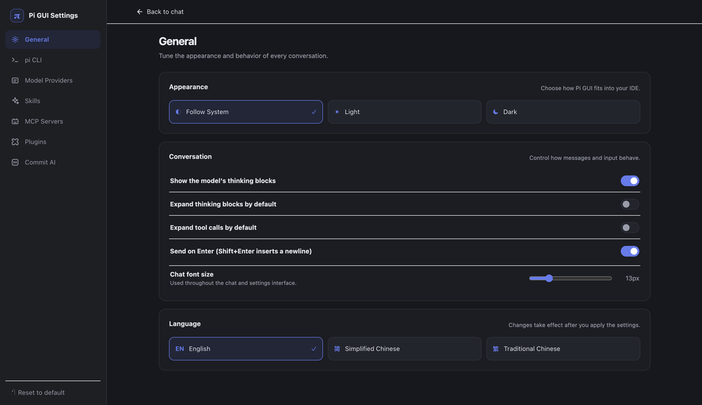

常规设置

### 常规设置逐项说明

- **主题**：跟随系统、浅色、深色。控制 Pi GUI 的界面外观。
- **显示模型的思考块**：控制聊天中是否呈现模型返回的思考内容。
- **默认展开思考块**：开启后打开会话时思考区默认展开；关闭时折叠显示。
- **默认展开工具调用**：控制工具调用详情打开时的默认折叠状态。
- **按 Enter 发送**：开启后 Enter 发送、Shift+Enter 换行；关闭后按相反方式输入。
- **聊天字体大小**：调节聊天和设置界面的文字字号；可使用旁边的重置图标恢复默认。
- **语言**：English、简体中文或繁体中文；修改应用后生效。

### MCP 服务配置

MCP 页面管理 Pi 通过扩展加载的 MCP 配置。全局配置位于 `~/.pi/agent/mcp.json`，项目配置位于当前项目 `.pi/mcp.json`。服务编辑器字段如下：

| 字段 | 说明 |
| --- | --- |
| 服务名称 | 服务配置的标识名称 |
| 作用域 | 全局或项目；项目级需要打开项目 |
| 传输方式 | `stdio`、`streamable-http` 或 `sse` |
| 启动命令 / 参数 | `stdio` 服务的可执行命令及参数（每行一个） |
| 服务 URL | HTTP/SSE 服务地址 |
| 启动方式 | 按需启动或立即启动 |
| 环境变量 / 请求头 | JSON 对象，用于进程环境变量或 HTTP headers |

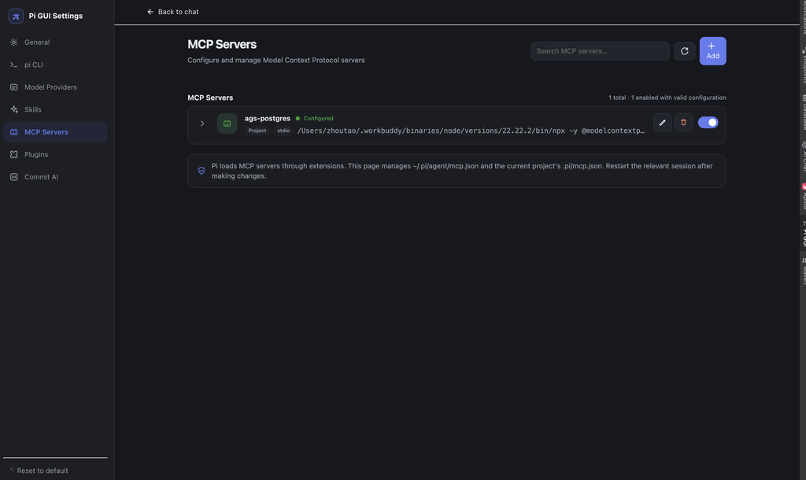

mcp服务

可通过卡片开关启停服务，展开卡片查看详情，或使用编辑/删除按钮维护配置。有效且启用的数量会显示在页面摘要中。为保护密钥，已有环境变量和请求头不会回显；留空保存会保留原值。环境变量和请求头必须是有效 JSON。配置更新后需要重新启动对应会话才会加载新设置。

### 技能与插件的安装范围

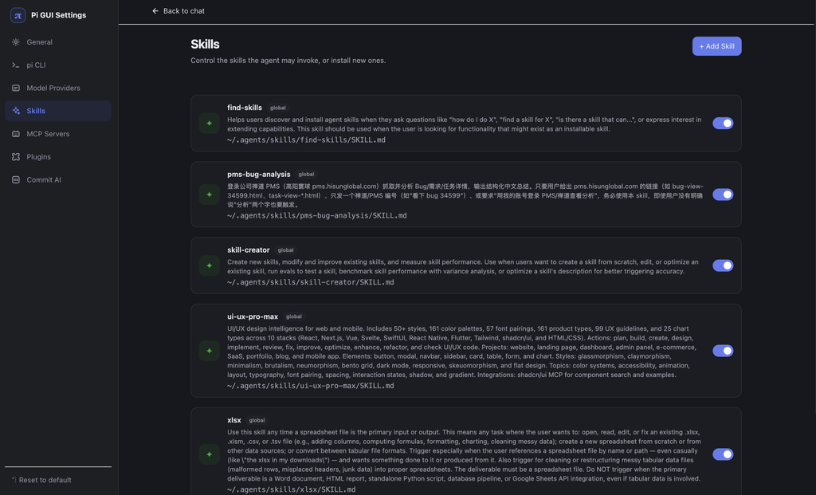

skills服务

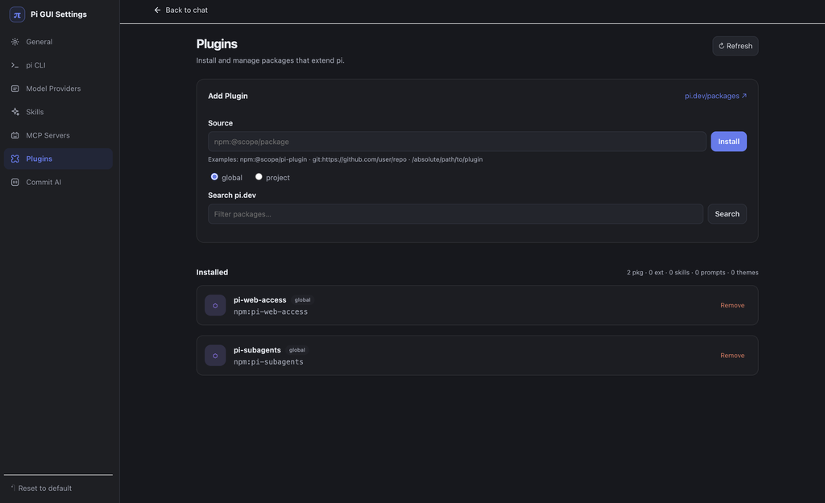

插件服务

- **技能**：在技能页点击添加并搜索，结果可安装到全局或当前项目；已安装技能可查看说明及来源路径，并切换启用状态。项目范围依赖当前打开的项目。
- **插件包**：可通过 pi.dev 搜索，也可粘贴来源，例如 `npm:@scope/pi-plugin`、`git:https://github.com/user/repo` 或绝对本地路径。安装时选择全局/项目范围；已安装清单可移除包。插件包可提供扩展、技能、提示词和主题。
- 安装技能会运行 `npx skills add`，安装插件包会运行 `pi install`；这些操作会从所选来源下载并运行代码，安装对话框会显示来源和范围。

### Commit AI 设置与使用

[figure not shown]

commit ai

在 **Commit AI** 页面设置生成模型、生成语言和附加提示词。模型可跟随当前聊天模型；附加提示词会与所选 Git diff 一起作为生成要求，长度上限为 2000 字符，可随时恢复默认。使用时在 IDE Commit 面板选择变更，再点击提交消息工具栏的 Pi 图标。生成内容只写入可编辑的提交消息框；用户可修改后自行决定是否提交。

### 导入供应商与凭据隐私

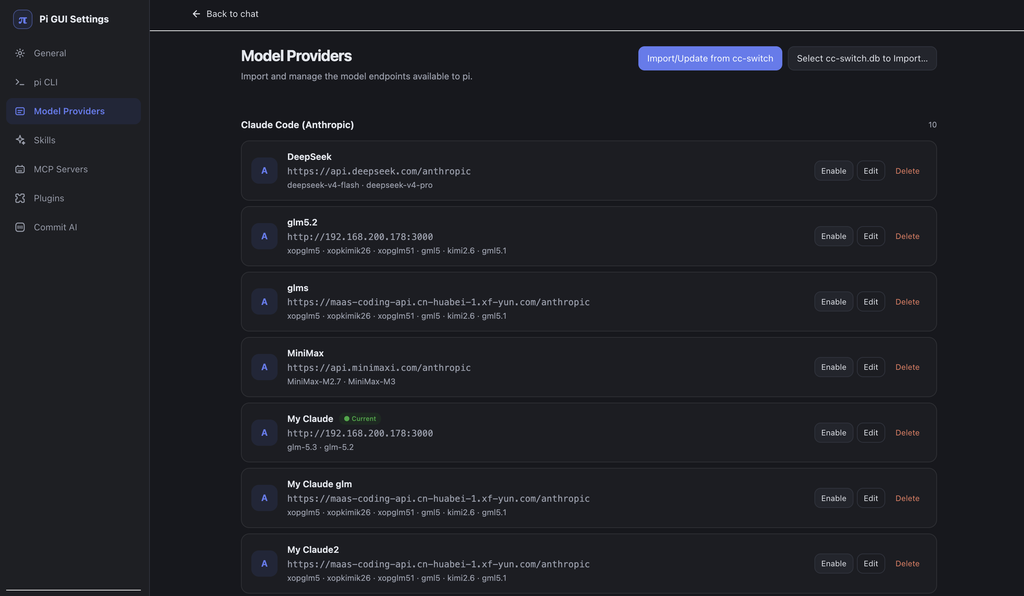

模型供应商

Model Providers 可自动从 cc-switch 导入配置，兼容其 `cc-switch.db` 和 `config.json`；也可以手动选择数据库文件。首次导入前会出现明确授权说明。授权范围包括读取选中的 cc-switch 配置或数据库，以及用于识别配置的 `ANTHROPIC_AUTH_TOKEN`、`ANTHROPIC_API_KEY`、`OPENAI_API_KEY` 环境变量；插件不会读取完整环境变量。

被选中的配置会复制到本机 `~/.pi/agent/providers.import.json` 及 `~/.pi/agent/models.json` 中由 Pi GUI 管理的条目。凭据保留在本机；Pi GUI 不会把凭据发送给插件开发者，也不收集遥测。调用所选供应商时，本机 pi CLI 会将请求凭据发送给该供应商。若拒绝授权，凭据文件和 AI 凭据环境变量不会被读取，供应商导入保持禁用。

## 9. 常见问题

| 现象 | 检查方法 |
| --- | --- |
| 工具窗口不显示 | 确认插件已启用；通过 **View → Tool Windows → Pi GUI** 或右侧 Pi GUI 图标重新打开 |
| 显示找不到 pi | 在 Pi GUI 设置的 **pi CLI** 页面设置可执行文件路径；确认该路径在 IDE 进程环境中可运行 |
| 供应商/模型列表为空 | 先导入或添加供应商，确认 Base URL、模型列表和凭据，再启用目标供应商 |
| 请求鉴权失败 | 检查供应商凭据与 API 地址。cc-switch 导入需要先明确授权 |
| 想压缩但界面提示上下文太少 | 短会话不建议压缩；确需执行可输入 `/compact` |
| 扩展命令未出现在补全中 | 等待 pi 返回动态命令，或执行 `/reload` 重新加载扩展、技能与提示词 |
| 文件没有出现在改动列表 | 列表以工具返回成功的 `write`/`edit` 为准；检查智能体是否实际完成修改 |

## 10. 技术与数据边界

- Pi GUI 启动本机 `pi --mode rpc` 子进程，使用逐行 JSON 消息流通信。
- 读取会话文件不启动 agent；只有发送消息才启动，恢复会话时通过 `--session <file>` 加载。
- 附件中的非图片文件以路径引用交给 agent 的工具读取；图片按支持类型内联传给模型。
- AI 请求由本机 pi CLI 发往所选供应商；凭据导入需明确授权。
- 插件 UI 使用 IDE 内置 JCEF 与原生 Swing/IntelliJ 组件，不依赖远端网页作为 UI。

回到顶部 ↑